# SDS Homework 1

Alvetreti, Corrias, Di Nino, Omar

2022-12-02

## Exercise 1: Stat4Race

To achive the fastest possible algorithm we started implementing a vectorized method.

The logic behind it is the following: - for each iteration we draw the same number of values of the sample x from Y - we check for each x if the correspondent y is greater or not - finally we save the number of x that found a greater y

At the end of each iteration the size of x to check decreases, but it takes each time more time to find a bigger y.

For this reason we implemented an early stop option which will stop the simulation after 99.9% of x-es found a bigger y.

To improve even more the performance we implemented a parallel version of the method above which takes advantage of all the available cores of the CPU to speed up the process.

```r
parallel_sim <- function(M) {

  # Set seed
  set.seed(13112221)

  # Core Logic
  vectorized_sim <- function(x, early_stop = T) {

    sim_size <- length(x)

    stopped_counts <- c() # Count x-es for each stop time

    # If early_stop is selected we stop after 99.9% x-es
    # have found a y bigger than themselves
    x_lim <-ifelse(early_stop, sim_size %/% 1000, 0)

    while(length(x) > x_lim) {

      y <- runif(length(x)) # Draw a y for each x

      stopped_counts <- append(stopped_counts, sum(y < x))

      x <- x[x <= y] # Remove stopped x-es
    }

    return(stopped_counts)
  }

  # Parallelize iterations
  stopped_counts <- foreach(x_chunk = irunif(M %/% n_cores,
                                             count = n_cores)) %dopar% {
    vectorized_sim(x_chunk)
  }

  # Make each list of the same length
  equalize_vectors <- function(list) {
    Map(function(x, y) {c(x, rep(0, y))},
        list,
        max(lengths(list)) - lengths(list))
  }

  stopped_counts <- equalize_vectors(stopped_counts)

  # Sum each list and normalize
  return(Reduce("+", stopped_counts) / M)

}
```

Compare the parallel simulation with size 1000000 with the actual target distribution.

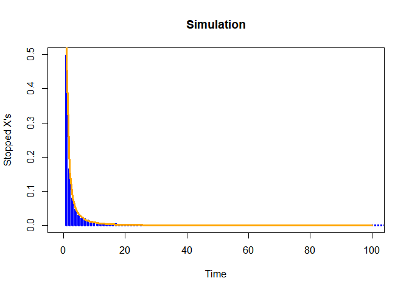

```r
compare_sim <- function(x) {

  plot(c(1 : length(x)), x,
       type = "h",
       xlab = "Time",
       ylab = "Stopped X's",
       xlim = c(-1, 100),
       col = "blue",
       lwd = 4,
       main = ("Simulation")
  )

  # Target Distribution
  target_distro <- function(t) (t > 0) / (t^2 + t)

  curve(target_distro, col = "orange", lwd = 3, add = T)
}

compare_sim(parallel_sim(1000000))
```

We evaluated our 3 different approaches for 6 different simulation sizes. Below we can observe a benchmark report of them.

|  | 100 | 1000 | 10000 | 1e+05 | 1e+06 | 1e+07 |
| --- | --- | --- | --- | --- | --- | --- |
| Vectorized | NA | NA | NA | NA | NA | NA |
| Vectorized Approximated | 0.1124439 | 0.0141952 | 0.0145271 | 0.048871 | 0.4129498 | 3.5812042 |
| Parallell (Approximated) | 0.5133991 | 0.0676391 | 0.0904832 | 0.082185 | 0.1531789 | 0.9758809 |

Finally we used the fastest method to evaluate how the simulation size impact over the approximation of the target Distribution.

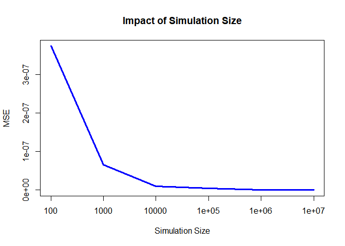

```r
MSEs <- c()

for (m in mm) {

  sim <- parallel_sim(m)

  # Get points from the target distribution
  target_distro <- function(t) (t > 0) / (t^2 + t)
  target_points <- target_distro(c(1:length(sim)))

  # Calculate the gap between the two
  diff <- (target_points - sim)

  # Get the mean square error
  MSEs <- append(MSEs, mean(diff^2))

}

plot(MSEs,
     type = "l",
     main = "Impact of Simulation Size",
     xlab = "Simulation Size",
     xaxt = "n",
     ylab = "MSE",
     col = "blue",
     lwd = 3
)
axis(1, at=1:length(mm), labels=mm) # Add simulation sizes as x-values label
```

## Exercise 2.1: Privatization

```r
quadratic_distance<-function(x, f, g){
  return((f(x) - g(x))^2)
}

# associated distro as a function (we will need it to integrate)
original_distro <- function(x){
  return(dbeta(x, 10, 10))
}

#  histogram as a step function (again we need it to integrate later)
P_cap<-function(x){
  pos<-(x %/% (1/m))

  return(original_histo$density[pos+1])
}

# priv_histo as a function, needed to integrate
Q_cap <- function(x){
  pos<-(x %/% (1/m))

  return(priv_histo$counts[pos+1])
}
```

Setting parameters

```r
n <- 1000       # number of observations
m <- 30         # number of bins

epsilon <- 0.1  # fixing epsilon
```

Getting original distributions and histograms

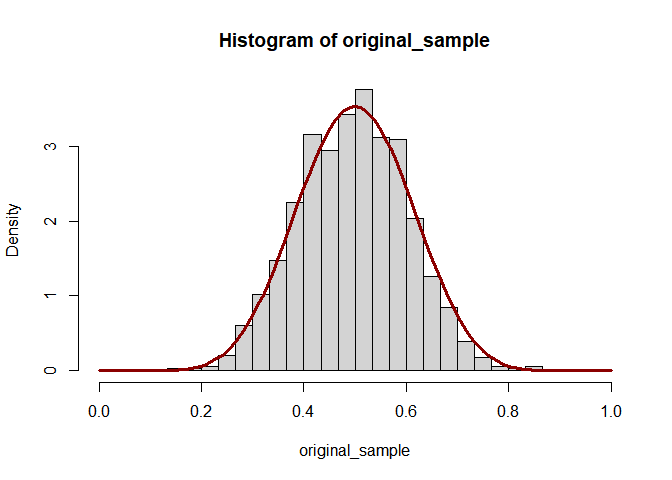

```r
# original sample
original_sample <- rbeta(n,10,10)

# histogram and curve
original_histo = hist(original_sample,
             breaks = c(0:m)*1/m ,
             xlim = c(0,1),
             prob = T)
curve(original_distro(x),
      col='darkred',
      lwd=3,
      add=T)
```

Getting privatized histogram

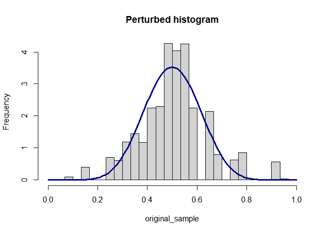

```r
# saving the hist structure
priv_histo<-original_histo

# noise used to privatize our data set
noise <- rlaplace(m,scale=(2/epsilon),location = 0)

# adding the noise, this is D_j
priv_histo$counts <- priv_histo$counts + noise

# taking the max between (0,D_j), this is D_j tilde
priv_histo$counts <- (priv_histo$counts > 0) * priv_histo$counts

# normalizing, we want that sum(counts)=m, so that sum(counts/m)=1
priv_histo$counts <- m*priv_histo$counts/sum(priv_histo$counts)

# plotting the new hist
plot(priv_histo,add=F, main = 'Perturbed histogram')
curve(original_distro(x),
      col='darkblue',
      lwd=3,
      add=T)
```

```r
# Quadratic Distance between original_distro and P_cap
integrate(function(x){quadratic_distance(x,P_cap,original_distro)},0,1,subdivisions = 2000)
```

```
## 0.0298169 with absolute error < 7.2e-05
```

```r
# Quadratic Distance between original_distro and Q_cap
integrate(function(x){quadratic_distance(x,Q_cap,original_distro)},0,1,subdivisions = 2000)
```

```
## 0.3727565 with absolute error < 6.5e-05
```

The following function repeats everything is shown above M times, save the values each time and compute their means.

```r
MISE_PAR <- function(M, m, n, epsilon1,epsilon2){

  MISE <- function(M, m, n, epsilon1, epsilon2){

  library("VGAM")

  original_distro <- function(x){
    return(dbeta(x, 10, 10))
  }

  quadratic_distance<-function(x, f, g){
    return((f(x) - g(x))^2)
  }
  Q_cap1 <- function(x){
  pos<-(x %/% (1/m))

  return(epsilon1_histo$density[pos+1])
  }

  Q_cap2 <- function(x){
  pos<-(x %/% (1/m))

  return(epsilon2_histo$density[pos+1])
  }

  P_cap<-function(x){
  pos<-(x%/%(1/m))

  return(original_histo$density[pos+1])
  }


  Original_MISE <-array(NA,M)
  epsilon1_MISE <-array(NA,M)
  epsilon2_MISE <-array(NA,M)

  for(i in 1:M){

    original_histo = hist(rbeta(n,10,10),
                          breaks = c(0:m)*1/m ,
                          plot = F)

    epsilon1_histo<-original_histo

    noise <- rlaplace(m,scale=(2/epsilon1),location = 0)

    epsilon1_histo$counts <- epsilon1_histo$counts + noise

    epsilon1_histo$counts <- (epsilon1_histo$counts > 0) * epsilon1_histo$counts

    epsilon1_histo$counts <- m*epsilon1_histo$counts/sum(epsilon1_histo$counts)

    epsilon1_histo$density <- epsilon1_histo$counts

    epsilon2_histo<-original_histo

    noise <- rlaplace(m,scale=(2/epsilon2),location = 0)

    epsilon2_histo$counts <- epsilon2_histo$counts + noise

    epsilon2_histo$counts <- (epsilon2_histo$counts > 0) * epsilon2_histo$counts

    epsilon2_histo$counts <- m*epsilon2_histo$counts/sum(epsilon2_histo$counts)

    epsilon2_histo$density <- epsilon2_histo$counts

    try(Original_MISE[i] <- integrate(function(x){quadratic_distance(x,P_cap,original_distro)},0,1,subdivisions = 2000)$value)


    try(epsilon1_MISE[i] <- integrate(function(x){quadratic_distance(x,Q_cap1,original_distro)},0,1,subdivisions = 2000)$value)

    try(epsilon2_MISE[i] <- integrate(function(x){quadratic_distance(x,Q_cap2,original_distro)},0,1,subdivisions = 2000)$value)
  }


  Original_MISE <- sum(Original_MISE)
  epsilon1_MISE <- sum(epsilon1_MISE)
  epsilon2_MISE <- sum(epsilon2_MISE)


  return(c(Original_MISE,epsilon1_MISE,epsilon2_MISE))
}
  # as always here 2 is the number of cores
  mise<-foreach(idx= c(1:2),.combine="+") %dopar% {

    (MISE(M%/%2,m,n,epsilon1,epsilon2))

  }
  return(mise/M)
}

print("MISE:")
```

```
## [1] "MISE:"
```

```r
MISE_PAR(500,30,100,0.1,0.001)
```

```
## [1] 0.2825807 3.3132911 4.3666507
```

```r
MISE_TABLE <- matrix(data = NA,nrow = 10,ncol = 3)
colnames(MISE_TABLE) = c("TRUE MISE", "eps = 0.1","eps = 0.001")
rownames(MISE_TABLE) = c(1:10)

for(i in 1:10) {
  x<-c("m", i*5)
  rownames(MISE_TABLE)[i] <- paste(x,collapse = "=")
}
```

Computing the Table Note: for “extremely bad integrand behaviour” we return NA

```r
# Associate the MISE corresponding to m given by the row
for(i in 1:10){
  try(MISE_TABLE[i,] <- MISE_PAR(500, (i*5), 1000, 0.1,0.001))
}
knitr::kable(MISE_TABLE)
```

|  | TRUE MISE | eps = 0.1 | eps = 0.001 |
| --- | --- | --- | --- |
| m=5 | 0.2327484 | 0.2463684 | NA |
| m=10 | 0.0874843 | 0.1426938 | 3.746371 |
| m=15 | 0.0485365 | 0.1593530 | 4.108041 |
| m=20 | 0.0376827 | 0.2401446 | 4.101382 |
| m=25 | 0.0368931 | 0.3234314 | 4.087449 |
| m=30 | 0.0359694 | 0.4317859 | 4.228511 |
| m=35 | 0.0384927 | 0.5313224 | 4.242519 |
| m=40 | 0.0430057 | 0.6362446 | 4.388463 |
| m=45 | 0.0472350 | 0.7509406 | 4.321622 |
| m=50 | 0.0525062 | 0.8669816 | 4.360736 |

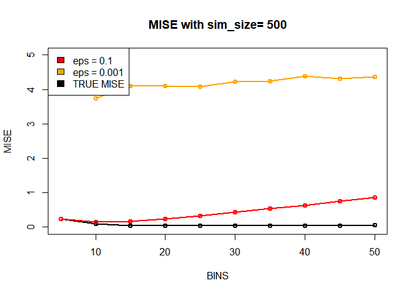

```r
plot(x=seq(5,50,5),y=MISE_TABLE[, "TRUE MISE"],
     type="o",
     ylim=c(0,5),
     lwd=2,
     ylab ="MISE",
     xlab="BINS",
     main = "MISE with sim_size= 500")

points(x=seq(5,50,5), y=MISE_TABLE[,"eps = 0.1"],
       type="o",
       lwd=2,
       col="red")

points(x=seq(5,50,5), y=MISE_TABLE[,"eps = 0.001"],
       type="o",
       lwd=2,
       col="orange")

legend("topleft",legend = c("eps = 0.1","eps = 0.001","TRUE MISE"),fill =c("red","orange","black"))
```

# 2.2 Simulating over a mixed Beta distribution

We have to define a new model for our population of interest, that is going to be the mixture of two beta random variables. Given $X_1 \sim Beta(\alpha_1,\beta_1)$ and $X_2 \sim Beta(\alpha_2, \beta_2)$, we are going to define the random variable
$$\begin{align}
X \sim \pi ⋅ p_{X_1}(x) + (1-\pi) ⋅ p_{X_2}(x)
\end{align}$$

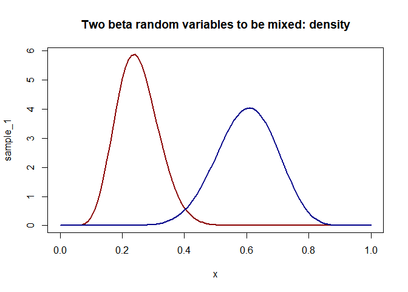

```r
sample_1 <- function(x) dbeta(x,10,30)
sample_2 <- function(x) dbeta(x,15,10)

plot(sample_1, lwd = 2, col='darkred', main = 'Two beta random variables to be mixed: density')
plot(sample_2, lwd = 2, col='darkblue', add=T)
```

We set our threshold for discriminate the two populations that generates the mixted model.

```r
p_p <- 0.25
```

We now define a new distribution from mixing this two betas.

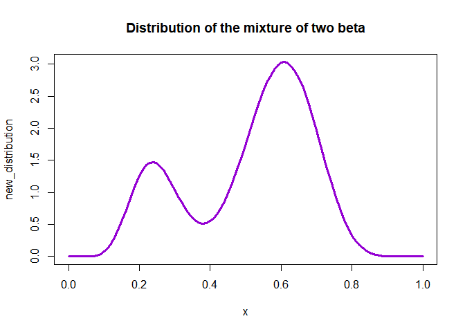

```r
new_distribution <- function(x) {
  return (p_p *sample_1(x) + (1-p_p)*sample_2(x))
}

plot(new_distribution, col='darkviolet', lwd = 3, main = 'Distribution of the mixture of two beta')
```

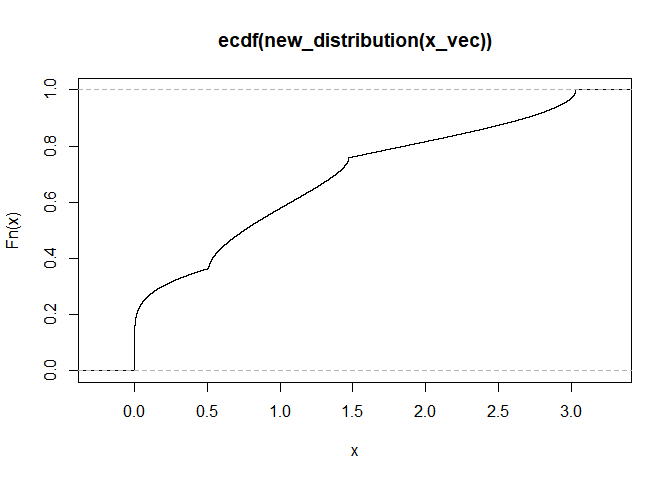

```r
x_vec <- seq(0,1,by=.0001)
plot(ecdf(new_distribution(x_vec)))
```

Next one is just to verify that our new defined distribution is actually a normalized PDF.

```r
integrate(new_distribution, lower=0, upper=1, subdivisions = 2000)
```

```
## 1 with absolute error < 1e-05
```

Now we set the same parameters as before to perform the sampling

```r
M <- 1000        # simulation size
n <- 1000        # number of observations
m <- 30          # number of bins

epsilon <- 0.1   # fixing epsilon
```

We need a method to randomly sample from a mixed beta: the next implemented function does so setting a threshold and sampling uniformly the probability to sample from the first or the second population.

```r
r_mixed_beta <- function(n_samples, alpha1, beta1, alpha2, beta2, thresh) {
  sampled <- rep(NA, n_samples)
  for (i in 1:n_samples) {
    pp <- runif(1)
    if (pp <= thresh) {
    sampled[i] <- rbeta(1,alpha1,beta1)
    }
    if(pp > thresh) {
    sampled[i] <- rbeta(1,alpha2,beta2)
    }
  }
  return(sampled)
}
```

Now we just run the previous function for the values we chose for the mixed model and plot our new histogram.

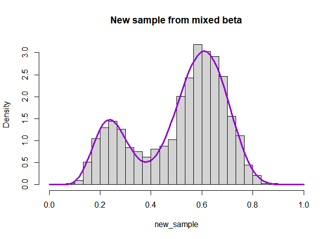

```r
set.seed(13112)
new_sample <- r_mixed_beta (n, 10, 30, 15, 10, .25)

new_histo <- hist(new_sample,
             breaks = c(0:m)*1/m ,
             xlim = c(0,1),
             main = 'New sample from mixed beta',
             prob = T)

curve(new_distribution(x),
      col='darkviolet',
      lwd=3,
      add=T)
```

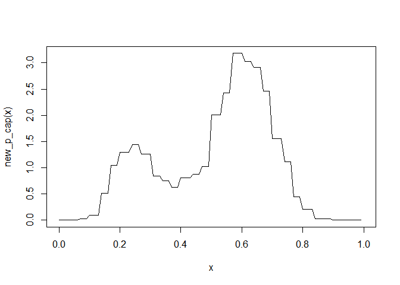

```r
new_p_cap<-function(x){
  pos<-(x%/%(1/m))
  return(new_histo$density[pos+1])
}

x_vec <- seq(0,1,by=.0001)
curve(new_p_cap(x))
```

Now we just follow the pattern we walked in the previous simulation, so we are defining a laplacian noise, and we are going to perturbe our histogram.

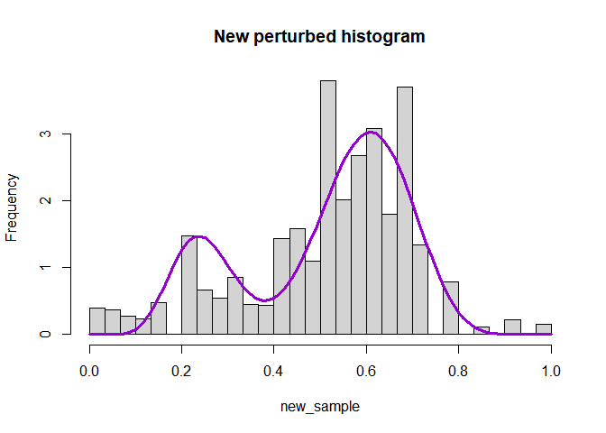

```r
new_priv_histo <- new_histo

noise <- rlaplace(m,scale=(2/epsilon),location = 0)
counts <- new_priv_histo$counts
counts <- counts + noise
counts <- (counts > 0) * counts
counts <- m*counts/sum(counts)

new_priv_histo$counts <- counts

new_q_cap<-function(x){
  pos<-(x%/%(1/m))
  return(new_priv_histo$counts[pos+1])
}

plot(new_priv_histo, main = 'New perturbed histogram')
curve(new_distribution(x), lwd = 3, col = 'darkviolet',add=T)
```

What we have done up to now is basically the visualization of the setting of one single iteration of the simulation process. Let’s have a look to the quadratic distance to complete this setting.

```r
integrate(function(x){quadratic_distance(x,new_p_cap,new_distribution)},0,1,subdivisions = 2000)
```

```
## 0.02512516 with absolute error < 6.5e-05
```

```r
integrate(function(x){quadratic_distance(x,new_q_cap,new_distribution)},0,1,subdivisions = 2000)
```

```
## 0.3878953 with absolute error < 1.5e-05
```

Now we are going to define and perform the actual simulation. We just recollect all the function that are needed in the simulation.

```r
r_mixed_beta <- function(n_samples, alpha1, beta1, alpha2, beta2, thresh) {
  sampled <- rep(NA, n_samples)
  for (i in 1:n_samples) {
    pp <- runif(1)
    if (pp <= thresh) {
    sampled[i] <- rbeta(1,alpha1,beta1)
    }
    if(pp > thresh) {
    sampled[i] <- rbeta(1,alpha2,beta2)
    }
  }
  return(sampled)
}
```

Now we define a new MISE function.

```r
new_MISE_PAR <- function(M,m,n,epsilon){
  sample_1 <- function(x) dbeta(x,10,30)
  sample_2 <- function(x) dbeta(x,15,10)

  p_p <- 0.25
  new_distribution <- function(x) {
    return (p_p *sample_1(x) + (1-p_p)*sample_2(x))
  }

  quadratic_distance<-function(x,f,g){
    return((f(x)-g(x))^2)
  }

  r_mixed_beta <- function(n_samples, alpha1, beta1, alpha2, beta2, thresh) {
    sampled <- rep(NA, n_samples)
    for (i in 1:n_samples) {
      pp <- runif(1)
      if (pp <= thresh) {
        sampled[i] <- rbeta(1,alpha1,beta1)
        }
      if(pp > thresh) {
        sampled[i] <- rbeta(1,alpha2,beta2)
        }
      }
  return(sampled)
    }

  quadratic_distance<-function(x,f,g){
    return((f(x)-g(x))^2)

  }

  new_MISE <- function(M,m,n,epsilon){

  original_MISE <-c()
  priv_MISE <- c()

  for(i in 1:M) {
    new_sample <- r_mixed_beta (n, 10, 30, 15, 10, .25)
    new_histo <- hist(new_sample,
                          breaks = c(0:m)*1/m ,
                          plot = F)

    new_priv_histo <- new_histo
    noise <- rlaplace(m,scale=(2/epsilon),location = 0)
    counts <- new_priv_histo$counts
    counts <- counts + noise
    counts <- (counts > 0) * counts
    counts <- m*counts/sum(counts)

    new_priv_histo$counts <- counts
    new_p_cap<-function(x){
        pos<-(x%/%(1/m))
        return(new_histo$density[pos+1])
      }

    new_q_cap<-function(x){
      pos<-(x%/%(1/m))
      return(new_priv_histo$counts[pos+1])
      }

    original_MISE<- append(original_MISE,integrate(function(x){quadratic_distance(x,new_p_cap,new_distribution)},0,1,subdivisions = 2000)$value)
    priv_MISE <- append(priv_MISE,integrate(function(x){quadratic_distance(x,new_q_cap,new_distribution)},0,1,subdivisions = 2000)$value)
  }

  original_MISE <- sum(original_MISE)
  priv_MISE <- sum(priv_MISE)

  return(c(original_MISE,priv_MISE))
}

  # as always here 2 is the number of cores
  new_mised<-foreach(idx= c(1:2),.combine="+") %dopar% {
    (new_MISE(M%/%2,m,n,epsilon))
  }
  return(new_mised/M)
}

print("MISE:")
```

```
## [1] "MISE:"
```

```r
new_MISE_PAR(1000,30,100,0.1)
```

```
## [1] 0.294364 2.871162
```

```r
new_MISE_table <-matrix(data = NA,nrow = 46,ncol = 2)
colnames(new_MISE_table)= c("TRUE MISE","PRIV MISE")
rownames(new_MISE_table)= c(1:46);
for(i in 1:46) {x<-c("m",i+4);rownames(new_MISE_table)[i]<- paste(x,collapse = "=")}

for(i in 1:46){
  try(new_MISE_table[i,]<-new_MISE_PAR(1000,(i+4),1000,0.1))
}
knitr::kable(new_MISE_table)
```

|  | TRUE MISE | PRIV MISE |
| --- | --- | --- |
| m=5 | 0.3673807 | 0.3836880 |
| m=6 | 0.1628759 | 0.1830561 |
| m=7 | 0.1436625 | 0.1727989 |
| m=8 | 0.1356693 | 0.1746667 |
| m=9 | 0.1098307 | 0.1573285 |
| m=10 | 0.0889725 | 0.1481071 |
| m=11 | 0.0757327 | 0.1476991 |
| m=12 | 0.0671467 | 0.1475526 |
| m=13 | 0.0604474 | 0.1519262 |
| m=14 | 0.0550434 | 0.1618341 |
| m=15 | 0.0506144 | 0.1720954 |
| m=16 | 0.0470216 | 0.1903524 |
| m=17 | 0.0445902 | 0.2001587 |
| m=18 | 0.0421102 | 0.2148272 |
| m=19 | 0.0409376 | 0.2316137 |
| m=20 | 0.0394619 | 0.2468356 |
| m=21 | 0.0386703 | 0.2645839 |
| m=22 | 0.0374306 | 0.2778218 |
| m=23 | 0.0373475 | 0.3016768 |
| m=24 | 0.0370284 | 0.3093035 |
| m=25 | 0.0362518 | 0.3334389 |
| m=26 | 0.0367878 | 0.3466923 |
| m=27 | 0.0373191 | 0.3705783 |
| m=28 | 0.0374970 | 0.3987083 |
| m=29 | 0.0378989 | 0.4111672 |
| m=30 | 0.0382269 | 0.4339095 |
| m=31 | 0.0383767 | 0.4437107 |
| m=32 | 0.0388014 | 0.4823829 |
| m=33 | 0.0385136 | 0.4818057 |
| m=34 | 0.0392528 | 0.5232664 |
| m=35 | 0.0399983 | 0.5383899 |
| m=36 | 0.0402351 | 0.5548057 |
| m=37 | 0.0413678 | 0.5796692 |
| m=38 | 0.0427611 | 0.5977487 |
| m=39 | 0.0432989 | 0.6283368 |
| m=40 | 0.0430440 | 0.6342338 |
| m=41 | 0.0444577 | 0.6788840 |
| m=42 | 0.0457226 | 0.6767344 |
| m=43 | 0.0463161 | 0.6998719 |
| m=44 | 0.0466916 | 0.7302891 |
| m=45 | 0.0472437 | 0.7577448 |
| m=46 | 0.0480918 | 0.7649280 |
| m=47 | 0.0499955 | 0.7959986 |
| m=48 | 0.0492593 | 0.8099209 |
| m=49 | 0.0502806 | 0.8335240 |
| m=50 | 0.0511585 | 0.8524661 |

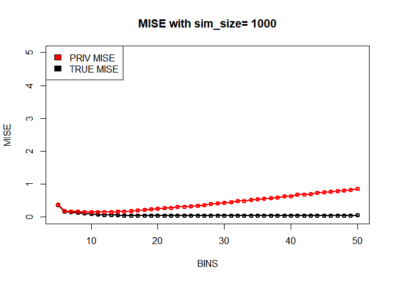

```r
plot(x=c(5:50),y=new_MISE_table[, "TRUE MISE"],
     type="o",
     ylim=c(0,5),
     lwd=2,
     ylab ="MISE",
     xlab="BINS",
     main = "MISE with sim_size= 1000")

points(x=c(5:50), y = new_MISE_table[,"PRIV MISE"],
       type="o",
       lwd=2,
       col="red")

legend("topleft",legend = c("PRIV MISE","TRUE MISE"),fill =c("red","black"))
```

## Analysis

```r
best_one_first_scenario <- MISE_TABLE[10,]
best_one_second_scenario <- new_MISE_table[10,]

print(best_one_first_scenario)
```

```
##   TRUE MISE   eps = 0.1 eps = 0.001
##  0.05250619  0.86698160  4.36073594
```

```r
print(best_one_second_scenario)
```

```
##  TRUE MISE  PRIV MISE
## 0.05504345 0.16183406
```

# 2.4 Bonus question

Let $A=\{a_1,a_2,...,a_n\}$ and $B=\{b_1,b_2,...,b_n\}$ be two neighbors datasets, i.e. $\exists ! i \in \{1,...,n\} : a_i\not=b_i$.

Let $Z=\{z_1,...,z_n\}$ be the privatized dataset obtained trough the privatized histogram method.

We must show that:
$$sup_z\
\frac{\mathbb{q}(z_1,...,z_n\ |\ a_1,...,a_n)}{\mathbb{q}(z_1,...,z_n\
|\ b_1,...,b_n)}\leq e^\epsilon.$$

Since the privatized dataset is obtained by randomly sampling from the distribution of the privatized histogram, the privatization of the data is assured if the histograms are privatized.

Hence let’s consider the histograms associated to $A$ and $B$. There are 2 possibilities:

1. $a_i$ and $b_i$ fall in the same bin,
2. $a_i$ and $b_i$ are not in the same bin.

In the first case the histogram is per se a privatization of the data set, hence let’s focus on the second case.

Let $H'=\{h'_1,...,h'_m\}$ and $H''=\{h''_1,...,h''_m\}$ be the heights of the unnormalized histograms associated to $A$ and $B$. Let $T=\{t_1,...,t_n\}$ be the heights of the unnormalized privatized histogram we are given.

Now, we must show that:

$$sup_{(t_1,...,t_m)}\
\frac{\mathbb{q}(t_1,...,t_m\ |\
h'_1,...,h'_m)}{\mathbb{q}(t_1,...,t_m\ |\
h''_1,...,h''_m)}\leq e^\epsilon.$$

Let $H$ be whatever is the right one between $H'$ and $H''$ that actually generates $T$.

$T$ is then obtained by summing $H$ and $m$ samples from a laplacian distribution
$$f(x)=(\epsilon/4)\
e^{-(\epsilon/2)|x|}$$
with $0$ mean and $8/\epsilon^2$ variance.

Let $V=\{v_1,...,v_m\}$ be that sample, then:
$$\forall i \in \{1,..,m\},
t_i=h_i+v_i$$

Since $v_i$ are sampled independently, and $h_i$ are given (hence fixed),we have that
$$\mathbb{q}(t_1,...,t_m|h_1,...,h_m)=\prod_{i=1}^m
\ f(t_i-h_i)$$

Finally we just have to show that:
$$sup_{(t_1,...,t_m)} \frac{\prod_{i=1}^m \
f(t_i-h'_i)}{\prod_{i=1}^m \ f(t_i-h''_i)}\leq
e^{\epsilon}$$

For construction we have that $H'$ and $H''$ are equal for all but $2$ heights:

we are in the second case so $a_i$ and $b_i$ are not in the same bin, so there must be $2$ bins, namely $k$ and $j$ such that

A): $|h'_k-h''_k|=1$ and $|h'_j-h''_j|=1$.

Hence:
$$\forall t: \frac{\prod_{i=1}^m \
f(t_i-h'_i)}{\prod_{i=1}^m \ f(t_i-h''_i)}=
\frac{f(t_k-h'_k)f(t_j-h'_j)}{f(t_k-h''_k)f(t_j-h''_j)}$$

$$\frac{f(t_k-h'_k)f(t_j-h'_j)}{f(t_k-h''_k)f(t_j-h''_j)}=
\frac{e^{-(\epsilon/2)(|t_k-h'_k|+|t_j-h'_j|)}}{e^{-(\epsilon/2)(|t_k-h''_k|+|t_j-h''_j|)}}$$

$$=e^{(\epsilon/2)\{(|t_k-h''_k|+|t_j-h''_j|)-(|t_k-h'_k|+|t_j-h'_j|)\}}$$

$$=
e^{(\epsilon/2)\{(|t_k-h''_k|-|t_k-h'_k|)+(|t_j-h''_j|-|t_j-h'_j|)\}}$$

$$\leq e^{(\epsilon/2) \
|(|t_k-h''_k|-|t_k-h'_k|)|}
e^{(\epsilon/2) \ |(|t_j-h''_j|-|t_j-h'_j|)|}$$

using $|(|a|-|b|)|\leq |a-b|$, that’s equal to

$$= e^{(\epsilon/2) \
(|h''_k-h'_k|)} \
e^{(\epsilon/2) \ (|h''_j-h'_j|)}$$

by (A) that’s equal to
$$=e^{(\epsilon/2)}
\ e^{(\epsilon/2)}=e^\epsilon.$$
In conclusion we have established that:

$$\forall t,\frac{\mathbb{q}(t_1,...,t_m\
|\ h'_1,...,h'_m)}{\mathbb{q}(t_1,...,t_m\ |\
h''_1,...,h''_m)}\leq e^\epsilon$$

and hence that :
$$sup_ t\
\frac{\mathbb{q}(t_1,...,t_m\ |\
h'_1,...,h'_m)}{\mathbb{q}(t_1,...,t_m\ |\
h''_1,...,h''_m)}\leq e^\epsilon.$$

NB: in the proof shown we assumed that $(v_i<-h_i)$ never happens, and hence that $max(0,t_i)$ is always $t_i$, just to not have a too heavy notation, the “general” proof is similar.